# R for Bio Data Science

Oriade Latifah Simpson

Spring 2022

**Group Number : 20**

**Instructions**:

Please hand in T7 and only T7.

When you hand in, please hand in the knitted html file, with visible code and plot.

Deadline for handing in is Thursday 23:59.

Remember to add group number and names to your output.

Due Date: **10 February, 2022 11:59 PM**

```r
library(tidyverse)
library(remotes)
library(viridisLite)
#library(datamicroarray)
#remotes::install_github("ramhiser/datamicroarray")
```

```r
gravier = readRDS(file = "Data/gravier.rdata")
#gravier
```

Information about the data is found here: https://github.com/ramhiser/datamicroarray

**The data**

```r
#data('gravier', package = 'datamicroarray')
set.seed(676571)

cancer_data=mutate(as_tibble(pluck(gravier,"x")),
                   y=pluck(gravier,"y"),
                   pt_id=1:length(pluck(gravier, "y")),
                   age=round(rnorm(length(pluck(gravier,"y")),
                                   mean=55,sd=10),1))
cancer_data=rename(cancer_data,event_label=y)
cancer_data$age_group=cut(cancer_data$age,
                          breaks=seq(10,100,
                                     by=10))
```

**T7: Pick your favourite gene and create densitograms of expression levels stratified on the variable event_label**

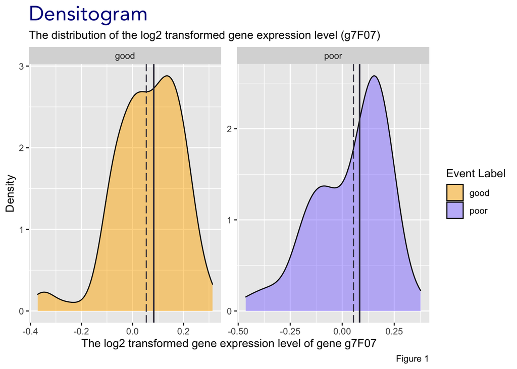

```r
ggplot(
  data = cancer_data ,

  mapping = aes(x = g7F07, fill = event_label))+

  geom_density(alpha = 0.5)+

  # Add lines for the mean and median gene expression levels.
  geom_vline(aes(xintercept = mean(g7F07)), colour = "#363445", lwd = 0.5, linetype = "longdash") +
  geom_vline(aes(xintercept = median(g7F07)), colour = "#363445", lwd = 0.7, linetype = "solid")+

  # Add a theme.
  theme_gray()+

  # Add a facet based on the event label.
  facet_wrap(~event_label, scales="free")+

  # Add a colour palette you like.
  scale_fill_manual(values = c("#ffb400", "#9080ff"))+
  # scale_fill_manual(values = viridisLite::viridis(2))

  # Add some labels.
  labs(
    y = "Density",
    x = "The log2 transformed gene expression level of gene g7F07",
    title = "Densitogram",
    subtitle = "The distribution of the log2 transformed gene expression level (g7F07)",
    caption = "Figure 1",

    # change the name of the legend.
    fill="Event Label") +
    theme(plot.title=element_text(family="Avenir",
                                  face="bold",
                                  size=20, colour = "darkblue"))
```

The distribution of the expression level of the gene g7F07 is shown above.

Good (outcomes) represent the patients who have no metastatic or loco-regional recurrence after diagnosis.

Poor (outcomes) represent the patients who have early metastasis or metastatic relapse.

There are two peaks in the distribution of the data.

- Colour palettes information: https://www.heavy.ai/blog/12-color-palettes-for-telling-better-stories-with-your-data
- Change line width: https://stackoverflow.com/questions/14794599/how-to-change-line-width-in-ggplot
- Paper: A Prognostic DNA Signature for T1T2 Node-Negative Breast Cancer Patients by Eleonore Gravier et.al https://onlinelibrary-wiley-com.ep.fjernadgang.kb.dk/doi/full/10.1002/gcc.20820